# PSTAT 131 HW 5 WRITE UP

Katherine Bayt

2022-05-14

## QUESTION 1

```r
pokemon_clean <- pokemon %>%
  clean_names()
```

The clean_names function mainly effected the names of the variables. For example, Type.1 becomes type_1, Sp..Atk becomes sp_atk. Thus, it appears the clean_names converts the datasets variables to follow normal R conventions for names, including removing all uppercase in the variable names. This appears to be helpful so that (1) we can easily identify a variable name in the code because they now follow normal name conventions, and (2) we dont run into errors with the code by missing an uppercase letter.

## QUESTION 2

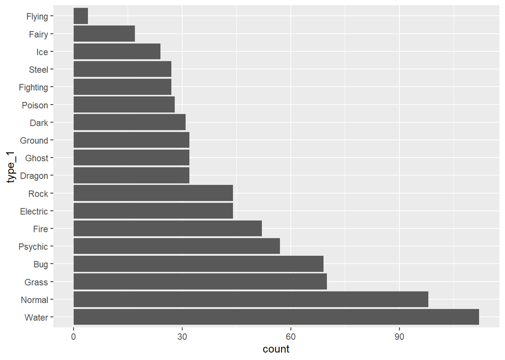

```r
pokemon_clean %>%
  ggplot(aes(x=forcats::fct_infreq(type_1))) +
  geom_bar() +
  labs(x="type_1") +
  coord_flip()
```

```r
# 18 outcomes
# smallest: flying, fairy
# filter type_1
pokemon_clean <- pokemon_clean %>%
  filter(type_1 == "Bug" | type_1 == "Fire" |
           type_1 == "Grass" | type_1 == "Normal" |
           type_1 == "Water" | type_1 == "Psychic")

# convert type_1 and legendary to factors
pokemon_clean$type_1 <- factor(pokemon_clean$type_1)
pokemon_clean$legendary <- factor(pokemon_clean$legendary)
view(pokemon_clean)
```

There are 18 classes of the outcome variable, type_1. The classes Flying and Fairy appear to have the least amount of Pokemon.

## QUESTION 3

```
## [1] 318  13
```

```
## [1] 140  13
```

```
## #  5-fold cross-validation using stratification
## # A tibble: 5 x 2
##   splits           id
##   <list>           <chr>
## 1 <split [252/66]> Fold1
## 2 <split [253/65]> Fold2
## 3 <split [253/65]> Fold3
## 4 <split [256/62]> Fold4
## 5 <split [258/60]> Fold5
```

Using a proportion of 0.7, I have 318 observations in the training set and 140 observations in the testing set. Stratifying on the folds will be useful so that each fold the data is trained with will have an equal distribution of the types of pokemon. For example, the type Psychic has about 50 less observations than the type Water, and our folds will only have about 63 observations so we don’t want to end up with a fold that doesn’t have any Psychic types in it. Thus, stratifying on type_1 will help train our model better so that it make better predictions with future data.

## QUESTION 4

```r
pokemon_recipe <- recipe(type_1 ~ legendary +
                           generation + sp_atk +
                           attack + speed + defense +
                           hp + sp_def, data = pokemon_train) %>%
  step_dummy(legendary, generation) %>%
  step_normalize(all_predictors())
```

## QUESTION 5

```r
# set up model
multi_reg <- multinom_reg(penalty = tune(),
                          mixture = tune()) %>%
  set_engine("glmnet")
# set up workflow
multi_wkflow <- workflow() %>%
  add_model(multi_reg) %>%
  add_recipe(pokemon_recipe)
# regular grid for penalty and mixture
# 10 levels each
pokemon_grid <- grid_regular(penalty(range=c(-5,5)),                           mixture(range(c(0,1))),
                             levels = 10)
pokemon_grid
```

```
## # A tibble: 100 x 2
##          penalty mixture
##            <dbl>   <dbl>
##  1      0.00001        0
##  2      0.000129       0
##  3      0.00167        0
##  4      0.0215         0
##  5      0.278          0
##  6      3.59           0
##  7     46.4            0
##  8    599.             0
##  9   7743.             0
## 10 100000              0
## # ... with 90 more rows
```

We have 100 different penalty and misture combinations that will be fit with 5 different folds. Thus we will be fitting 500 models total.

## QUESTION 6

```r
## fit the models to your folded data via tune_grid()
tune_res <- tune_grid(
  multi_wkflow,
  resamples = pokemon_folds,
  grid = pokemon_grid)
```

```
## ! Fold1: preprocessor 1/1: The following variables are not factor vectors and wil...
```

```
## ! Fold2: preprocessor 1/1: The following variables are not factor vectors and wil...
```

```
## ! Fold3: preprocessor 1/1: The following variables are not factor vectors and wil...
```

```
## ! Fold4: preprocessor 1/1: The following variables are not factor vectors and wil...
```

```
## ! Fold5: preprocessor 1/1: The following variables are not factor vectors and wil...
```

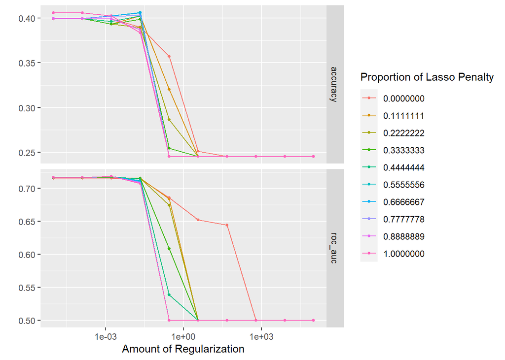

```r
# plot the results via autoplot()
autoplot(tune_res)
```

## QUESTION 7

```r
best_model <- select_best(tune_res,
                          metric = "roc_auc")
best_model
```

```
## # A tibble: 1 x 3
##   penalty mixture .config
##     <dbl>   <dbl> <chr>
## 1 0.00167   0.889 Preprocessor1_Model083
```

```r
# fit the model to the training set
# fit the model to the training set
# finalize_workflow(), fit(), and augment()
final_model <- finalize_workflow(multi_wkflow, best_model)
final_model
```

```
## == Workflow ====================================================================
## Preprocessor: Recipe
## Model: multinom_reg()
##
## -- Preprocessor ----------------------------------------------------------------
## 2 Recipe Steps
##
## * step_dummy()
## * step_normalize()
##
## -- Model -----------------------------------------------------------------------
## Multinomial Regression Model Specification (classification)
##
## Main Arguments:
##   penalty = 0.00166810053720006
##   mixture = 0.888888888888889
##
## Computational engine: glmnet
```

```r
final_model_fit <- fit(final_model, data=pokemon_train)
```

## QUESTION 8

```r
# get overall roc_auc value
augment(final_model_fit, new_data = pokemon_test) %>%
  roc_auc(truth = type_1, estimate = c(.pred_Bug,
                                       .pred_Fire, .pred_Grass, .pred_Normal,
                                       .pred_Psychic, .pred_Water))
```

```
## # A tibble: 1 x 3
##   .metric .estimator .estimate
##   <chr>   <chr>          <dbl>
## 1 roc_auc hand_till      0.681
```

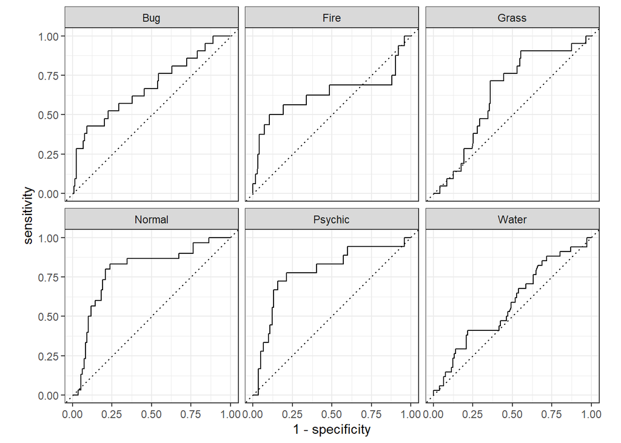

```r
# plots of different roc curves per level
augment(final_model_fit, new_data = pokemon_test) %>%
  roc_curve(type_1, estimate = c(.pred_Bug,
            .pred_Fire, .pred_Grass, .pred_Normal,
            .pred_Psychic, .pred_Water)) %>%
  autoplot()
```

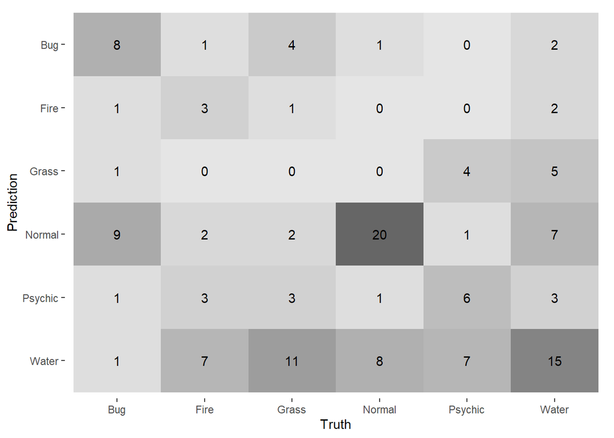

```r
# confusion matrix
augment(final_model_fit, new_data = pokemon_test) %>%
  conf_mat(type_1, estimate = .pred_class) %>%
  autoplot(type="heatmap")
```